```yaml
---
title: "ASSIGNMENT 6.1_Housing_Data"
author: "Bhushan Suryawanshi"
date: '2020-07-06'

---
```

[output not shown]

**a. Explain why you chose to remove data points from your ‘clean’ dataset.**

**Answer** - Ignored this question as its irrelevant here. (Ref Announcement for week.)

```r
library("readxl")
housing_data <- read_excel("week-6-housing.xlsx")
head(housing_data)
```

```
## # A tibble: 6 x 24
##   `Sale Date`         `Sale Price` sale_reason sale_instrument sale_warning
##   <dttm>                     <dbl>       <dbl>           <dbl> <chr>
## 1 2006-01-03 00:00:00       698000           1               3 <NA>
## 2 2006-01-03 00:00:00       649990           1               3 <NA>
## 3 2006-01-03 00:00:00       572500           1               3 <NA>
## 4 2006-01-03 00:00:00       420000           1               3 <NA>
## 5 2006-01-03 00:00:00       369900           1               3 15
## 6 2006-01-03 00:00:00       184667           1              15 18 51
## # ... with 19 more variables: sitetype <chr>, addr_full <chr>, zip5 <dbl>,
## #   ctyname <chr>, postalctyn <chr>, lon <dbl>, lat <dbl>,
## #   building_grade <dbl>, square_feet_total_living <dbl>, bedrooms <dbl>,
## #   bath_full_count <dbl>, bath_half_count <dbl>, bath_3qtr_count <dbl>,
## #   year_built <dbl>, year_renovated <dbl>, current_zoning <chr>,
## #   sq_ft_lot <dbl>, prop_type <chr>, present_use <dbl>
```

**b. Create two variables; one that will contain the variables Sale Price and Square Foot of Lot (same variables used from previous assignment on simple regression) and one that will contain Sale Price and several additional predictors of your choice. Explain the basis for your additional predictor selections.**

#sales_price_with_sq_ft_lot <- housing_data[,c(“Sale Price”,“sq_ft_lot”)]

```r
cor(housing_data$'Sale Price', housing_data$square_feet_total_living)^2 * 100
```

```
## [1] 20.66499
```

```r
cor.test(housing_data$'Sale Price', housing_data$square_feet_total_living)
```

```
##
##  Pearson's product-moment correlation
##
## data:  housing_data$"Sale Price" and housing_data$square_feet_total_living
## t = 57.884, df = 12863, p-value < 2.2e-16
## alternative hypothesis: true correlation is not equal to 0
## 95 percent confidence interval:
##  0.4407697 0.4681900
## sample estimates:
##       cor
## 0.4545876
```

```r
cor(housing_data$'Sale Price', housing_data$building_grade)^2 * 100
```

```
## [1] 15.30602
```

```r
cor.test(housing_data$'Sale Price', housing_data$building_grade)
```

```
##
##  Pearson's product-moment correlation
##
## data:  housing_data$"Sale Price" and housing_data$building_grade
## t = 48.214, df = 12863, p-value < 2.2e-16
## alternative hypothesis: true correlation is not equal to 0
## 95 percent confidence interval:
##  0.3764941 0.4057662
## sample estimates:
##       cor
## 0.3912291
```

```r
cor(housing_data$'Sale Price', housing_data$year_built)^2 * 100
```

```
## [1] 5.888934
```

```r
cor.test(housing_data$'Sale Price', housing_data$year_built)
```

```
##
##  Pearson's product-moment correlation
##
## data:  housing_data$"Sale Price" and housing_data$year_built
## t = 28.371, df = 12863, p-value < 2.2e-16
## alternative hypothesis: true correlation is not equal to 0
## 95 percent confidence interval:
##  0.2263401 0.2588660
## sample estimates:
##       cor
## 0.2426713
```

```r
cor(housing_data$'Sale Price', housing_data$bedrooms)^2 * 100
```

```
## [1] 5.083558
```

```r
cor.test(housing_data$'Sale Price', housing_data$bedrooms)
```

```
##
##  Pearson's product-moment correlation
##
## data:  housing_data$"Sale Price" and housing_data$bedrooms
## t = 26.247, df = 12863, p-value < 2.2e-16
## alternative hypothesis: true correlation is not equal to 0
## 95 percent confidence interval:
##  0.2090015 0.2418056
## sample estimates:
##       cor
## 0.2254675
```

```r
sales_price_with_sq_ft_lot <-  lm(housing_data$'Sale Price' ~ housing_data$sq_ft_lot, data = housing_data)
sales_price_with_others <- lm(housing_data$'Sale Price' ~ housing_data$sq_ft_lot + housing_data$square_feet_total_living + housing_data$building_grade, data = housing_data)
```

**c. Execute a summary() function on two variables defined in the previous step to compare the model results. What are the R2 and Adjusted R2 statistics? Explain what these results tell you about the overall model. Did the inclusion of the additional predictors help explain any large variations found in Sale Price?**

```r
summary(sales_price_with_sq_ft_lot)
```

```
##
## Call:
## lm(formula = housing_data$"Sale Price" ~ housing_data$sq_ft_lot,
##     data = housing_data)
##
## Residuals:
##      Min       1Q   Median       3Q      Max
## -2016064  -194842   -63293    91565  3735109
##
## Coefficients:
##                         Estimate Std. Error t value Pr(>|t|)
## (Intercept)            6.418e+05  3.800e+03  168.90   <2e-16 ***
## housing_data$sq_ft_lot 8.510e-01  6.217e-02   13.69   <2e-16 ***
## ---
## Signif. codes:  0 '***' 0.001 '**' 0.01 '*' 0.05 '.' 0.1 ' ' 1
##
## Residual standard error: 401500 on 12863 degrees of freedom
## Multiple R-squared:  0.01435,    Adjusted R-squared:  0.01428
## F-statistic: 187.3 on 1 and 12863 DF,  p-value: < 2.2e-16
```

```r
summary(sales_price_with_others)
```

```
##
## Call:
## lm(formula = housing_data$"Sale Price" ~ housing_data$sq_ft_lot +
##     housing_data$square_feet_total_living + housing_data$building_grade,
##     data = housing_data)
##
## Residuals:
##      Min       1Q   Median       3Q      Max
## -1943318  -115934   -42965    39043  3747512
##
## Coefficients:
##                                         Estimate Std. Error t value Pr(>|t|)
## (Intercept)                           -8.142e+04  2.810e+04  -2.898  0.00377
## housing_data$sq_ft_lot                 1.330e-01  5.723e-02   2.324  0.02016
## housing_data$square_feet_total_living  1.475e+02  4.889e+00  30.178  < 2e-16
## housing_data$building_grade            4.424e+04  4.348e+03  10.175  < 2e-16
##
## (Intercept)                           **
## housing_data$sq_ft_lot                *
## housing_data$square_feet_total_living ***
## housing_data$building_grade           ***
## ---
## Signif. codes:  0 '***' 0.001 '**' 0.01 '*' 0.05 '.' 0.1 ' ' 1
##
## Residual standard error: 358700 on 12861 degrees of freedom
## Multiple R-squared:  0.2132, Adjusted R-squared:  0.213
## F-statistic:  1161 on 3 and 12861 DF,  p-value: < 2.2e-16
```

**Answer:**

For the first model R-Squared value is 0.014, which means that sq_ft_lot accounts for 1.4% of the variation in sale price. However, when the other two predictors are included as well, this value increases to 0.213, or 21.3% of the variance in sale price. Therefore, if sq_ft_lot accounts for 1.4%, we can tell that square_fee_total_living and building_grade account for an additional 20.0%. So the inclusion of the two new predictors has explained quite a large amount of the variation in sale price. R-squared and adjusted r-squared for the model with additional predictors shows difference of 0% (0.213 - 0.213). Which means if the model were derived from the population rather than a sample it would account for 0% variance in the outcome.

**d. Considering the parameters of the multiple regression model you have created. What are the standardized betas for each parameter and what do the values indicate?**

```r
library("QuantPsyc")
lm.beta(sales_price_with_others)
```

```
##                housing_data$sq_ft_lot housing_data$square_feet_total_living
##                            0.01872256                            0.36113656
##           housing_data$building_grade
##                            0.11952538
```

**Answer:**

The standardized beta estimates tell us the number of standard deviations by which the outcome will change as a result of one standard deviation change in the predictor.

In this case, 1 standard deviation of change in Sq_ft_lot causes sales price to change by 0.019 standard deviation. 1 standard deviation change in square_feet_total_living causes sales price to change by 0.361 standard deviation and 1 standard deviation change in building_grade can cause 0.120 standard deviation change in sale price.

**e. Calculate the confidence intervals for the parameters in your model and explain what the results indicate.**

```r
confint(sales_price_with_others, level = 0.95)
```

```
##                                               2.5 %        97.5 %
## (Intercept)                           -1.365003e+05 -2.634307e+04
## housing_data$sq_ft_lot                 2.079828e-02  2.451639e-01
## housing_data$square_feet_total_living  1.379562e+02  1.571221e+02
## housing_data$building_grade            3.571437e+04  5.275855e+04
```

**Answer:**

The confidence interval shows that there is positive relation between all predictors and outcome. Also the 95% confidence interval range is not very big which means this sample if close to the beta of population.

**f. Assess the improvement of the new model compared to your original model (simple regression model) by testing whether this change is significant by performing an analysis of variance.**

```r
anova(sales_price_with_sq_ft_lot, sales_price_with_others)
```

```
## Analysis of Variance Table
##
## Model 1: housing_data$"Sale Price" ~ housing_data$sq_ft_lot
## Model 2: housing_data$"Sale Price" ~ housing_data$sq_ft_lot + housing_data$square_feet_total_living +
##     housing_data$building_grade
##   Res.Df        RSS Df  Sum of Sq      F    Pr(>F)
## 1  12863 2.0734e+15
## 2  12861 1.6551e+15  2 4.1823e+14 1624.9 < 2.2e-16 ***
## ---
## Signif. codes:  0 '***' 0.001 '**' 0.01 '*' 0.05 '.' 0.1 ' ' 1
```

**Answer:** The value in column labelled Pr(>F) is 2.2e−16 (i.e., 2.2 with the decimal place moved 16 places to the left, or a very small value indeed); we can say that sales_price_with_others significantly improved the fit of the model to the data compared to sales_price_with_sq_ft_lot.

**g. Perform casewise diagnostics to identify outliers and/or influential cases, storing each function’s output in a dataframe assigned to a unique variable name.**

```r
housing_data$standardized_residuals<- rstandard(sales_price_with_others)
head(housing_data$standardized_residuals)
```

```
##           1           2           3           4           5           6
## -0.09526631 -0.25749989 -0.30602206 -0.25859457 -0.20013735 -1.83622727
```

```r
housing_data$studentized_residuals<-rstudent(sales_price_with_others)
head(housing_data$studentized_residuals)
```

```
##           1           2           3           4           5           6
## -0.09526264 -0.25749054 -0.30601128 -0.25858519 -0.20012988 -1.83639662
```

```r
housing_data$cooks_distance<-cooks.distance(sales_price_with_others)
head(housing_data$cooks_distance)
```

```
##            1            2            3            4            5            6
## 3.020345e-07 2.155168e-06 2.761224e-06 3.074759e-06 1.905215e-06 1.108648e-03
```

```r
housing_data$dfbeta<-dfbeta(sales_price_with_others)
head(housing_data$dfbeta)
```

```
##   (Intercept) housing_data$sq_ft_lot housing_data$square_feet_total_living
## 1    15.53348           1.476123e-05                           0.001227376
## 2    38.42380           4.519048e-05                           0.002074116
## 3   -46.69060           5.226207e-05                          -0.008579373
## 4    18.77844          -4.558569e-06                           0.012611383
## 5   -43.25320           2.403663e-06                           0.003317644
## 6 -1375.07195           7.990754e-04                          -0.302595677
##   housing_data$building_grade
## 1                   -2.625498
## 2                   -6.295360
## 3                    7.133413
## 4                   -7.028207
## 5                    3.542687
## 6                  251.748864
```

```r
housing_data$dffit<-dffits(sales_price_with_others)
head(housing_data$dffit)
```

```
##            1            2            3            4            5            6
## -0.001099111 -0.002935992 -0.003323269 -0.003506871 -0.002760488 -0.066598878
```

```r
housing_data$leverage<-hatvalues(sales_price_with_others)
head(housing_data$leverage)
```

```
##            1            2            3            4            5            6
## 0.0001331006 0.0001299962 0.0001179247 0.0001838876 0.0001902239 0.0013134999
```

```r
housing_data$covariance_ratios<-covratio(sales_price_with_others)
head(housing_data$covariance_ratios)
```

```
##        1        2        3        4        5        6
## 1.000441 1.000421 1.000400 1.000474 1.000489 1.000577
```

**h. Calculate the standardized residuals using the appropriate command, specifying those that are +-2, storing the results of large residuals in a variable you create.**

```r
housing_data$large_residual <- housing_data$studentized_residuals > 2 | housing_data$studentized_residuals < -2
```

**i. Use the appropriate function to show the sum of large residuals.**

```r
sum(housing_data$large_residual)
```

```
## [1] 317
```

**j. Which specific variables have large residuals (only cases that evaluate as TRUE)?**

```r
housing_data[housing_data$large_residual, c('Sale Price', 'sq_ft_lot', 'square_feet_total_living',  'building_grade', "standardized_residuals")]
```

```
## # A tibble: 317 x 5
##    `Sale Price` sq_ft_lot square_feet_total_l~ building_grade standardized_resi~
##           <dbl>     <dbl>                <dbl>          <dbl>              <dbl>
##  1       265000    112650                 4920             10              -2.33
##  2      1390000    225640                  660              6               3.01
##  3       229000    236966                 3840             10              -2.04
##  4       390000     63162                 5800             11              -2.45
##  5      1588359      8752                 3360              9               2.16
##  6      1450000     14043                  900              6               3.15
##  7       163000     18498                 4710              9              -2.37
##  8       270000     89734                 5060             11              -2.49
##  9       200000    288367                 6880             10              -3.39
## 10       300000     55303                 4490             11              -2.16
## # ... with 307 more rows
```

**k. Investigate further by calculating the leverage, cooks distance, and covariance rations. Comment on all cases that are problematics.**

```r
housing_data[housing_data$large_residual, c("cooks_distance", "leverage", "covariance_ratios")]
```

```
## # A tibble: 317 x 3
##    cooks_distance leverage covariance_ratios
##             <dbl>    <dbl>             <dbl>
##  1       0.000841 0.000617             0.999
##  2       0.00391  0.00173              0.999
##  3       0.00135  0.00130              1.00
##  4       0.00139  0.000922             0.999
##  5       0.000172 0.000147             0.999
##  6       0.00102  0.000410             0.998
##  7       0.000903 0.000641             0.999
##  8       0.00106  0.000685             0.999
##  9       0.00885  0.00307              1.00
## 10       0.000676 0.000578             0.999
## # ... with 307 more rows
```

```r
cook_dist <- housing_data$cooks_distance > 1

sum(cook_dist)
```

```
## [1] 1
```

**Answer:**

Out of 317 large residuals only 1 value has cook distance greater than 1. Hence only 1 influential observation in the model. (Ref. - Discovering Statistics Using R (Field, Miles, and Field 2012, 424) )

```r
k <- 3
sample_size <- 12865
leverage <- k/sample_size
leverage
```

```
## [1] 0.0002331908
```

```r
leverage_data <- housing_data$cooks_distance > 0.0006 | housing_data$cooks_distance < 0.0009
sum(leverage_data)
```

```
## [1] 12865
```

```r
#Covariance ratio boundary

#CVRi > 1 + [3(k + 1)/n] = 1 + [3(3 + 1)/sample_size] = 1.0009;

#CVRi < 1 – [3(k + 1)/n] = 1 – [3(3 + 1)/sample_size] = 0.9991

cvr_min <- 1 + 12/12865

cvr_min
```

```
## [1] 1.000933
```

```r
cvr_max <- 1 - 12/12865

cvr_max
```

```
## [1] 0.9990672
```

```r
cvr_data <- housing_data$cooks_distance > cvr_min |  housing_data$cooks_distance < cvr_max

sum(cvr_data)
```

```
## [1] 12865
```

**l. Perform the necessary calculations to assess the assumption of independence and state if the condition is met or not.**

```r
#Need to import car library as Durbin Watson Test was not working.

library("car")
dwt(sales_price_with_others)
```

```
##  lag Autocorrelation D-W Statistic p-value
##    1       0.7402678     0.5194617       0
##  Alternative hypothesis: rho != 0
```

**Answer:** The Durbin Watson test reports a test statistic, with a value from 0 to 4, where:

- 2 is no autocorrelation.
- ‘0 to <2’ is positive autocorrelation (common in time series data).
- ‘>2 to 4’ is negative autocorrelation (less common in time series data).

**m. Perform the necessary calculations to assess the assumption of no multicollinearity and state if the condition is met or not.**

```r
vif(sales_price_with_others)
```

```
##                housing_data$sq_ft_lot housing_data$square_feet_total_living
##                              1.061258                              2.340696
##           housing_data$building_grade
##                              2.255639
```

```r
mean(vif(sales_price_with_others))
```

```
## [1] 1.885864
```

```r
#Tolerence Statistics
1/vif(sales_price_with_others)
```

```
##                housing_data$sq_ft_lot housing_data$square_feet_total_living
##                             0.9422776                             0.4272234
##           housing_data$building_grade
##                             0.4433334
```

**n. Visually check the assumptions related to the residuals using the plot() and hist() functions. Summarize what each graph is informing you of and if any anomalies are present.**

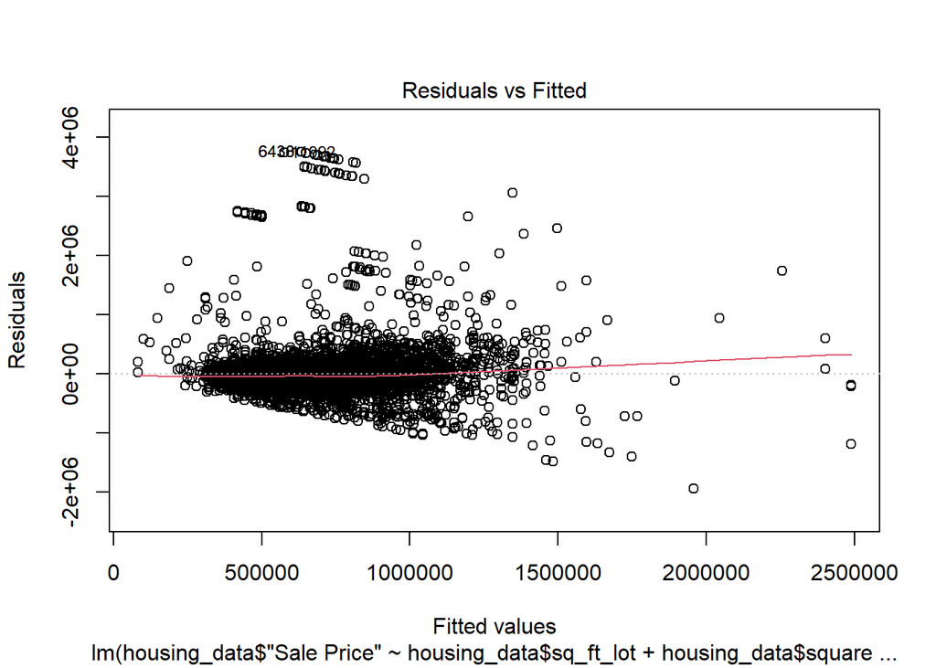

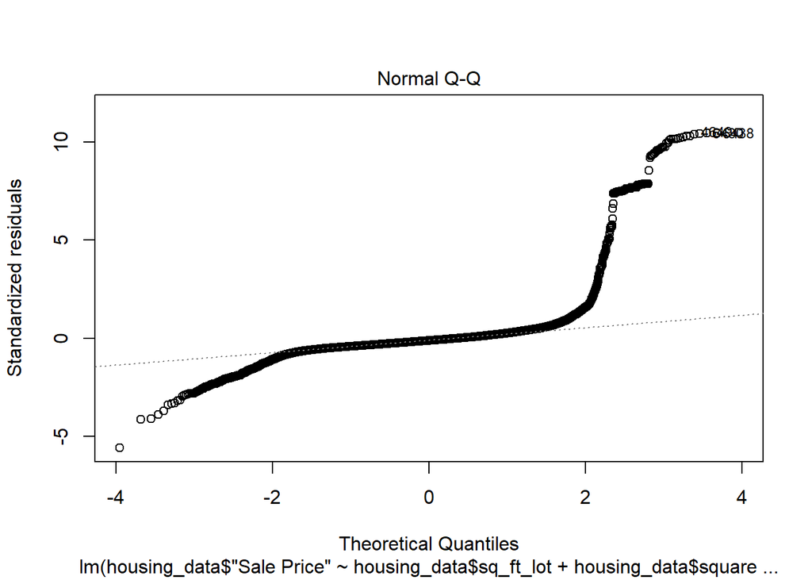

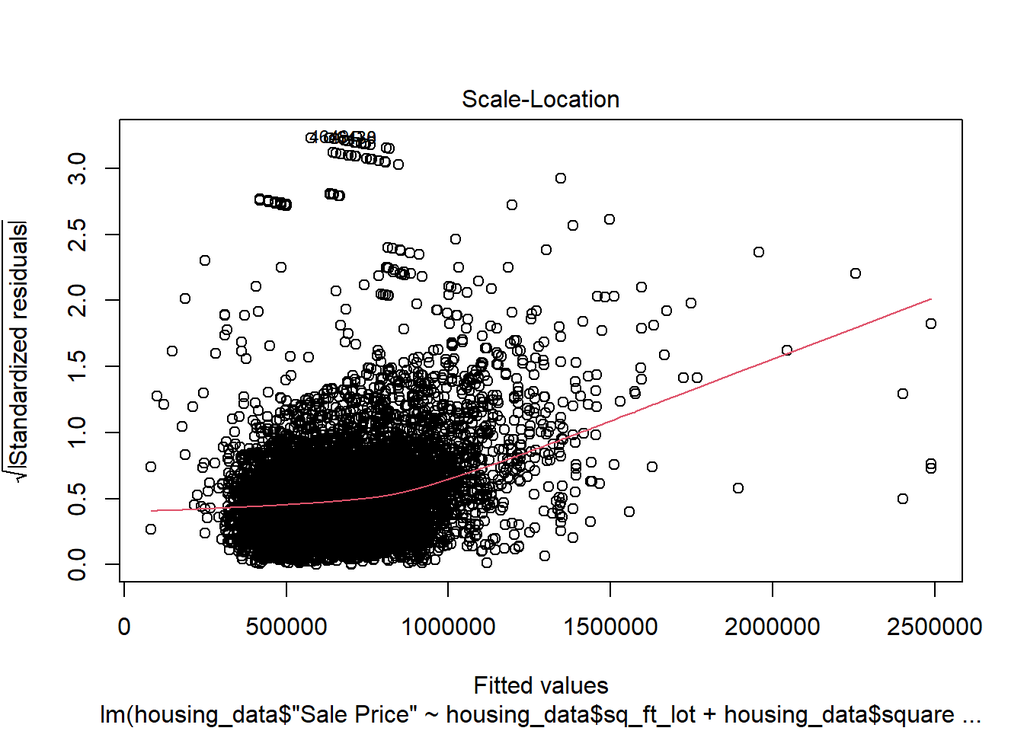

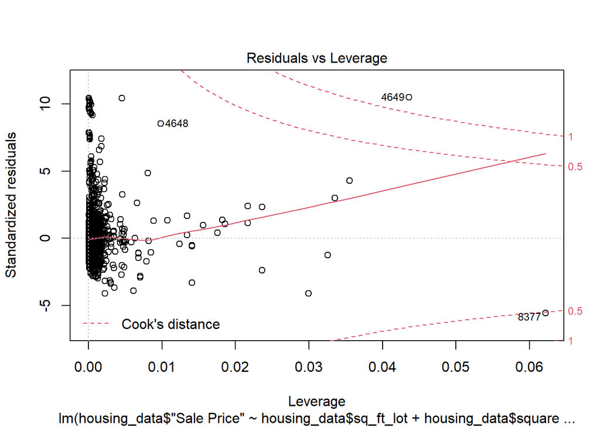

```r
plot(sales_price_with_others)
```

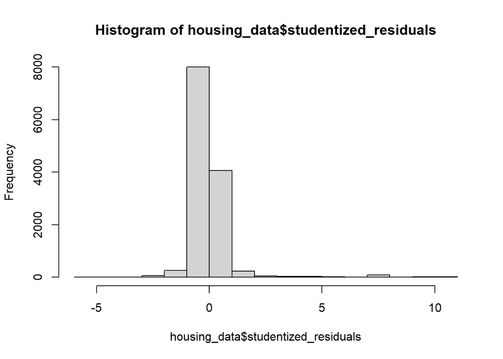

```r
hist(housing_data$studentized_residuals)
```

(Ref. - Discovering Statistics Using R (Field, Miles, and Field 2012, 428) )

**0. Overall, is this regression model unbiased? If an unbiased regression model, what does this tell us about the sample vs. the entire population model?**

Field, A., J. Miles, and Z. Field. 2012. *Discovering Statistics Using R*. SAGE Publications. https://books.google.com/books?id=wd2K2zC3swIC.